# Tugas 3

[figure not shown]

# PREDIKSI POLUSI UDARA MENGGUNAKAN METODE REGRESI LINEAR DENGAN TEKNIK MULTI-STEP

# Pendahuluan

## Latar Belakang

Polusi udara merupakan masalah lingkungan yang memiliki dampak besar terhadap kesehatan manusia dan kualitas lingkungan. Di kota-kota besar, polusi udara dapat menyebabkan berbagai masalah kesehatan, seperti gangguan pernapasan, penyakit jantung, dan meningkatkan angka kematian. Selain itu, polusi udara juga dapat merusak ekosistem, mengganggu kualitas hidup, dan mempengaruhi produktivitas ekonomi. Oleh karena itu, penting untuk memantau dan memprediksi tingkat polusi udara agar dapat diambil langkah-langkah mitigasi yang tepat.

Tingkat polusi udara yang berubah-ubah secara dinamis dipengaruhi oleh berbagai faktor, seperti cuaca, aktivitas industri, dan volume kendaraan. Oleh karena itu, prediksi polusi udara memerlukan model yang mampu menangani data yang bersifat sekuensial dan memiliki ketergantungan waktu. Salah satu metode yang efektif untuk memprediksi polusi udara adalah dengan menggunakan model Regresi Linear.

Model Regresi Linear multistep dapat digunakan untuk memprediksi polusi udara dalam beberapa langkah ke depan, yang memungkinkan pemerintah dan masyarakat untuk merencanakan langkah-langkah mitigasi polusi secara lebih efektif. Dengan memanfaatkan model ini, diharapkan prediksi polusi udara dapat lebih akurat dan membantu dalam pengambilan keputusan terkait pengelolaan kualitas udara.

## Tujuan

1. Mengembangkan model prediksi polusi udara menggunakan metode Regresi Linear multistep, yang dapat memproyeksikan kualitas udara dalam beberapa langkah waktu ke depan.
2. Memberikan rekomendasi untuk kebijakan pengelolaan polusi udara berdasarkan hasil prediksi yang diperoleh.

## Rumusan Masalah

Faktor-faktor apa saja yang paling mempengaruhi tingkat polusi udara dan bagaimana pengaruhnya terhadap hasil prediksi menggunakan model regresi linear?

# Data Understanding

```python
import numpy as np
    import pandas as pd
    import matplotlib.pyplot as plt
    from sklearn.model_selection import train_test_split
    from sklearn.preprocessing import MinMaxScaler
    from sklearn.linear_model import LinearRegression
    from sklearn.metrics import mean_squared_error
```

```python
from google.colab import drive
    drive.mount('/content/drive')
```

## Menampilkan Data

```python
# Path ke dataset
    dataset_path = '/content/drive/MyDrive/PSD/LSTM-Multivariate_pollution.csv'

    # Membaca dataset
    df = pd.read_csv(dataset_path)

    # Tampilkan 5 baris pertama
    print(df.head())
```

```
                  date  pollution  dew  temp   press wnd_dir  wnd_spd  snow  \
    0  2010-01-02 00:00:00      129.0  -16  -4.0  1020.0      SE     1.79     0
    1  2010-01-02 01:00:00      148.0  -15  -4.0  1020.0      SE     2.68     0
    2  2010-01-02 02:00:00      159.0  -11  -5.0  1021.0      SE     3.57     0
    3  2010-01-02 03:00:00      181.0   -7  -5.0  1022.0      SE     5.36     1
    4  2010-01-02 04:00:00      138.0   -7  -5.0  1022.0      SE     6.25     2

       rain
    0     0
    1     0
    2     0
    3     0
    4     0
```

```python
df_train = pd.read_csv('/content/drive/MyDrive/PSD/LSTM-Multivariate_pollution.csv')
    df_train
```

|  | date | pollution | dew | temp | press | wnd_dir | wnd_spd | snow | rain |
| --- | --- | --- | --- | --- | --- | --- | --- | --- | --- |
| 0 | 2010-01-02 00:00:00 | 129.0 | -16 | -4.0 | 1020.0 | SE | 1.79 | 0 | 0 |
| 1 | 2010-01-02 01:00:00 | 148.0 | -15 | -4.0 | 1020.0 | SE | 2.68 | 0 | 0 |
| 2 | 2010-01-02 02:00:00 | 159.0 | -11 | -5.0 | 1021.0 | SE | 3.57 | 0 | 0 |
| 3 | 2010-01-02 03:00:00 | 181.0 | -7 | -5.0 | 1022.0 | SE | 5.36 | 1 | 0 |
| 4 | 2010-01-02 04:00:00 | 138.0 | -7 | -5.0 | 1022.0 | SE | 6.25 | 2 | 0 |
| ... | ... | ... | ... | ... | ... | ... | ... | ... | ... |
| 43795 | 2014-12-31 19:00:00 | 8.0 | -23 | -2.0 | 1034.0 | NW | 231.97 | 0 | 0 |
| 43796 | 2014-12-31 20:00:00 | 10.0 | -22 | -3.0 | 1034.0 | NW | 237.78 | 0 | 0 |
| 43797 | 2014-12-31 21:00:00 | 10.0 | -22 | -3.0 | 1034.0 | NW | 242.70 | 0 | 0 |
| 43798 | 2014-12-31 22:00:00 | 8.0 | -22 | -4.0 | 1034.0 | NW | 246.72 | 0 | 0 |
| 43799 | 2014-12-31 23:00:00 | 12.0 | -21 | -3.0 | 1034.0 | NW | 249.85 | 0 | 0 |

43800 rows × 9 columns

## Menetukan Missing Value

```python
df = pd.read_csv('/content/drive/MyDrive/PSD/LSTM-Multivariate_pollution.csv')
    df.isnull().sum()
```

|  | 0 |
| --- | --- |
| date | 0 |
| pollution | 0 |
| dew | 0 |
| temp | 0 |
| press | 0 |
| wnd_dir | 0 |
| wnd_spd | 0 |
| snow | 0 |
| rain | 0 |

**dtype:** int64

**Kesimpulan**: Dapat dilihat bahwa tidak ada missing value pada dataset, maka tidak perlu ada penanganan lebih lanjut

## Explorasi Data (Numeric)

Selanjutnya melakukan explorasi data numerik dengan rincian sebagai berikut:

```python
df = pd.read_csv('/content/drive/MyDrive/PSD/LSTM-Multivariate_pollution.csv')
    df.describe()
```

|  | pollution | dew | temp | press | wnd_spd | snow | rain |
| --- | --- | --- | --- | --- | --- | --- | --- |
| count | 43800.000000 | 43800.000000 | 43800.000000 | 43800.000000 | 43800.000000 | 43800.000000 | 43800.000000 |
| mean | 94.013516 | 1.828516 | 12.459041 | 1016.447306 | 23.894307 | 0.052763 | 0.195023 |
| std | 92.252276 | 14.429326 | 12.193384 | 10.271411 | 50.022729 | 0.760582 | 1.416247 |
| min | 0.000000 | -40.000000 | -19.000000 | 991.000000 | 0.450000 | 0.000000 | 0.000000 |
| 25% | 24.000000 | -10.000000 | 2.000000 | 1008.000000 | 1.790000 | 0.000000 | 0.000000 |
| 50% | 68.000000 | 2.000000 | 14.000000 | 1016.000000 | 5.370000 | 0.000000 | 0.000000 |
| 75% | 132.250000 | 15.000000 | 23.000000 | 1025.000000 | 21.910000 | 0.000000 | 0.000000 |
| max | 994.000000 | 28.000000 | 42.000000 | 1046.000000 | 585.600000 | 27.000000 | 36.000000 |

## Distribusi Data

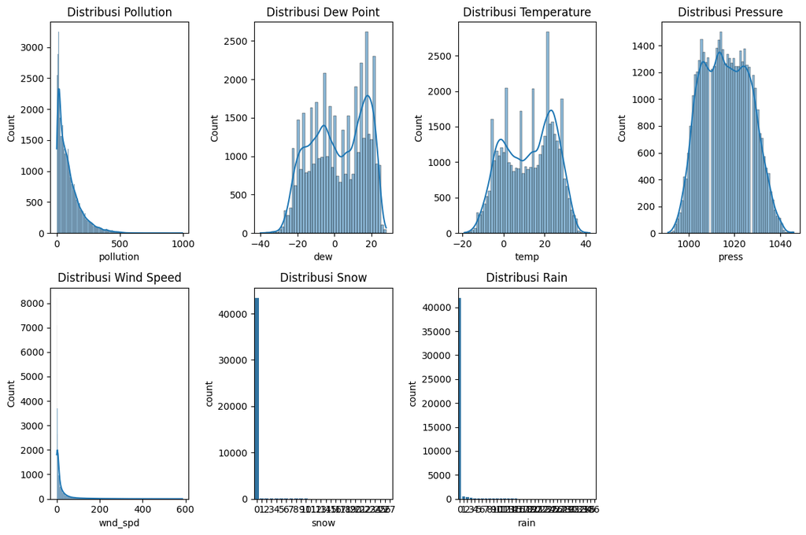

```python
!pip install seaborn
    import seaborn as sns
    # Menentukan ukuran plot
    plt.figure(figsize=(12, 8))

    # Menampilkan distribusi Pollution
    plt.subplot(2, 4, 1)
    sns.histplot(df['pollution'], kde=True)
    plt.title('Distribusi Pollution')

    # Menampilkan distribusi Dew Point
    plt.subplot(2, 4, 2)
    sns.histplot(df['dew'], kde=True)
    plt.title('Distribusi Dew Point')

    # Menampilkan distribusi Temperature
    plt.subplot(2, 4, 3)
    sns.histplot(df['temp'], kde=True)
    plt.title('Distribusi Temperature')

    # Menampilkan distribusi Pressure
    plt.subplot(2, 4, 4)
    sns.histplot(df['press'], kde=True)
    plt.title('Distribusi Pressure')

    # Menampilkan distribusi Wind Speed
    plt.subplot(2, 4, 5)
    sns.histplot(df['wnd_spd'], kde=True)
    plt.title('Distribusi Wind Speed')

    # Menampilkan distribusi Snow (bila merupakan data diskrit)
    plt.subplot(2, 4, 6)
    sns.countplot(x='snow', data=df)
    plt.title('Distribusi Snow')

    # Menampilkan distribusi Rain (bila merupakan data diskrit)
    plt.subplot(2, 4, 7)
    sns.countplot(x='rain', data=df)
    plt.title('Distribusi Rain')

    # Menampilkan plot
    plt.tight_layout()
    plt.show()
```

```python
print("Nama kolom dalam dataset:", df.columns.tolist())
```

```
Nama kolom dalam dataset: ['date', 'pollution', 'dew', 'temp', 'press', 'wnd_dir', 'wnd_spd', 'snow', 'rain']
```

```python
# Memastikan kolom yang diperlukan ada
    required_columns = ['pollution', 'dew', 'temp', 'press', 'wnd_dir', 'wnd_spd', 'snow', 'rain']
    df = df[required_columns]

    # Menghapus missing values
    df.dropna(inplace=True)
```

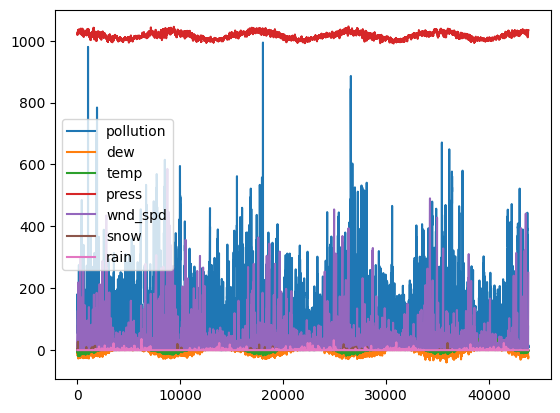

```python
df.plot()
```

## EDA

```python
df.info()  # Menampilkan informasi umum mengenai DataFrame, termasuk jumlah entri, jumlah kolom, tipe data setiap kolom, dan apakah ada nilai kosong (non-null).
    print('Ukuran data ', df.shape)  # Menampilkan ukuran data dalam format tuple (jumlah baris, jumlah kolom).
    df.dtypes  # Menampilkan tipe data dari setiap kolom dalam DataFrame.
```

```
<class 'pandas.core.frame.DataFrame'>
    RangeIndex: 43800 entries, 0 to 43799
    Data columns (total 8 columns):
     #   Column     Non-Null Count  Dtype
    ---  ------     --------------  -----
     0   pollution  43800 non-null  float64
     1   dew        43800 non-null  int64
     2   temp       43800 non-null  float64
     3   press      43800 non-null  float64
     4   wnd_dir    43800 non-null  object
     5   wnd_spd    43800 non-null  float64
     6   snow       43800 non-null  int64
     7   rain       43800 non-null  int64
    dtypes: float64(4), int64(3), object(1)
    memory usage: 2.7+ MB
    Ukuran data  (43800, 8)
```

|  | 0 |
| --- | --- |
| pollution | float64 |
| dew | int64 |
| temp | float64 |
| press | float64 |
| wnd_dir | object |
| wnd_spd | float64 |
| snow | int64 |
| rain | int64 |

**dtype:** object

## Korelasi Antar Fitur

```
Matriks Korelasi:
               pollution       dew      temp     press   wnd_spd      snow  \
    pollution   1.000000  0.157585 -0.090798 -0.045544 -0.234362  0.022226
    dew         0.157585  1.000000  0.824432 -0.778737 -0.296720 -0.034484
    temp       -0.090798  0.824432  1.000000 -0.827205 -0.154902 -0.092726
    press      -0.045544 -0.778737 -0.827205  1.000000  0.185380  0.069031
    wnd_spd    -0.234362 -0.296720 -0.154902  0.185380  1.000000  0.021876
    snow        0.022226 -0.034484 -0.092726  0.069031  0.021876  1.000000
    rain       -0.049045  0.125053  0.049037 -0.079840 -0.010137 -0.009553

                   rain
    pollution -0.049045
    dew        0.125053
    temp       0.049037
    press     -0.079840
    wnd_spd   -0.010137
    snow      -0.009553
    rain       1.000000
```

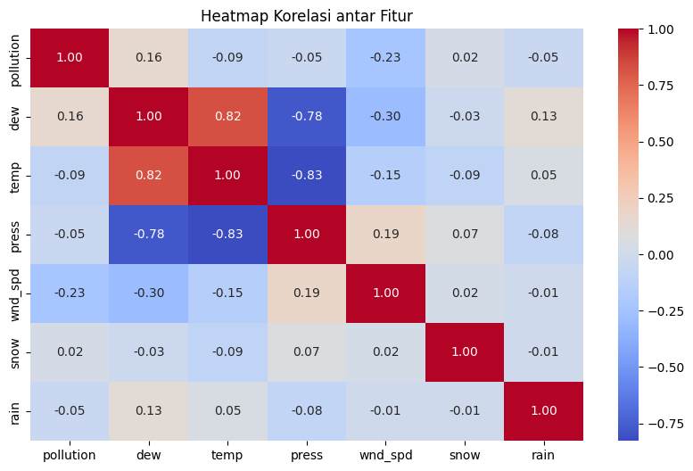

```python
import seaborn as sns
    # Menghitung korelasi antar fitur untuk subset yang diinginkan
    features = df[['pollution', 'dew', 'temp', 'press', 'wnd_spd', 'snow', 'rain']]
    correlation_matrix = features.corr()

    # Menampilkan matriks korelasi
    print("Matriks Korelasi:")
    print(correlation_matrix)

    # Menggambar heatmap untuk visualisasi korelasi
    plt.figure(figsize=(10, 6))
    plt.title("Heatmap Korelasi antar Fitur")
    sns.heatmap(correlation_matrix, annot=True, cmap='coolwarm', fmt=".2f")
    plt.show()
```

```python
# Deskripsi Statistik
    df.describe()
```

|  | pollution | dew | temp | press | wnd_spd | snow | rain |
| --- | --- | --- | --- | --- | --- | --- | --- |
| count | 43800.000000 | 43800.000000 | 43800.000000 | 43800.000000 | 43800.000000 | 43800.000000 | 43800.000000 |
| mean | 94.013516 | 1.828516 | 12.459041 | 1016.447306 | 23.894307 | 0.052763 | 0.195023 |
| std | 92.252276 | 14.429326 | 12.193384 | 10.271411 | 50.022729 | 0.760582 | 1.416247 |
| min | 0.000000 | -40.000000 | -19.000000 | 991.000000 | 0.450000 | 0.000000 | 0.000000 |
| 25% | 24.000000 | -10.000000 | 2.000000 | 1008.000000 | 1.790000 | 0.000000 | 0.000000 |
| 50% | 68.000000 | 2.000000 | 14.000000 | 1016.000000 | 5.370000 | 0.000000 | 0.000000 |
| 75% | 132.250000 | 15.000000 | 23.000000 | 1025.000000 | 21.910000 | 0.000000 | 0.000000 |
| max | 994.000000 | 28.000000 | 42.000000 | 1046.000000 | 585.600000 | 27.000000 | 36.000000 |

# preprocessing

## sliding windows

```python
import numpy as np
    import pandas as pd

    # Fungsi untuk membuat sliding windows
    def create_sliding_windows(data, window_size):
        X, y = [], []
        for i in range(len(data) - window_size):
            X.append(data[i:i + window_size])
            y.append(data[i + window_size])
        return np.array(X), np.array(y)

    # Menyiapkan data untuk sliding windows
    window_size = 3  # Ukuran window
    data_values = df[['pollution', 'dew', 'temp', 'press', 'wnd_spd', 'snow', 'rain']].values  # Menggunakan kolom data
    X, y = create_sliding_windows(data_values, window_size)

    # Buat nama kolom sesuai jumlah fitur dan window size
    feature_names = ['pollution', 'dew', 'temp', 'press', 'wnd_spd', 'snow', 'rain']
    columns = [f'{feature}_t-{window_size-j}' for j in range(window_size) for feature in feature_names]

    # Membuat DataFrame
    sliding_window_df = pd.DataFrame(X.reshape(X.shape[0], -1), columns=columns)

    # Menambahkan target ke DataFrame
    sliding_window_df['Target_pollution_t'] = y[:, 0]  # Target untuk fitur pertama

    # Menampilkan hasil
    print(sliding_window_df.head())
```

```
   pollution_t-3  dew_t-3  temp_t-3  press_t-3  wnd_spd_t-3  snow_t-3  \
    0          129.0    -16.0      -4.0     1020.0         1.79       0.0
    1          148.0    -15.0      -4.0     1020.0         2.68       0.0
    2          159.0    -11.0      -5.0     1021.0         3.57       0.0
    3          181.0     -7.0      -5.0     1022.0         5.36       1.0
    4          138.0     -7.0      -5.0     1022.0         6.25       2.0

       rain_t-3  pollution_t-2  dew_t-2  temp_t-2  ...  snow_t-2  rain_t-2  \
    0       0.0          148.0    -15.0      -4.0  ...       0.0       0.0
    1       0.0          159.0    -11.0      -5.0  ...       0.0       0.0
    2       0.0          181.0     -7.0      -5.0  ...       1.0       0.0
    3       0.0          138.0     -7.0      -5.0  ...       2.0       0.0
    4       0.0          109.0     -7.0      -6.0  ...       3.0       0.0

       pollution_t-1  dew_t-1  temp_t-1  press_t-1  wnd_spd_t-1  snow_t-1  \
    0          159.0    -11.0      -5.0     1021.0         3.57       0.0
    1          181.0     -7.0      -5.0     1022.0         5.36       1.0
    2          138.0     -7.0      -5.0     1022.0         6.25       2.0
    3          109.0     -7.0      -6.0     1022.0         7.14       3.0
    4          105.0     -7.0      -6.0     1023.0         8.93       4.0

       rain_t-1  Target_pollution_t
    0       0.0               181.0
    1       0.0               138.0
    2       0.0               109.0
    3       0.0               105.0
    4       0.0               124.0

    [5 rows x 22 columns]
```

# Pemodelan

```python
import numpy as np
    import pandas as pd
    from sklearn.preprocessing import MinMaxScaler
    from sklearn.model_selection import train_test_split
    import matplotlib.dates as mdates
    import matplotlib.pyplot as plt

    # Fungsi untuk membuat target yang digeser (multi-step forecasting)
    def create_shifted_targets(data, steps):
        targets = []
        for step in range(1, steps + 1):
            targets.append(data.shift(-step))  # Geser data untuk langkah ke depan
        return pd.concat(targets, axis=1)

    # Membaca dataset LSTM-Multivariate_pollution.csv
    data = pd.read_csv('/content/drive/MyDrive/PSD/LSTM-Multivariate_pollution.csv')

    # Memeriksa struktur dataset
    print(data.head())

    # Kolom yang relevan untuk fitur dan target
    features = ['pollution', 'dew', 'temp', 'press', 'wnd_spd', 'snow', 'rain']  # Fitur yang relevan
    target = 'pollution'  # Target adalah konsentrasi polusi (misalnya, PM2.5 atau 'pollution')

    # Membuat target yang digeser untuk multi-step forecasting
    steps = 2  # Prediksi 2 langkah ke depan (t+1, t+2)
    y_multi = create_shifted_targets(data[target], steps)

    # Menghapus NaN dari target yang digeser (y_multi)
    y_multi = y_multi.dropna()

    # Menyelaraskan fitur X dengan target y_multi setelah menghapus NaN
    X = data[features].loc[y_multi.index]

    # Verifikasi panjang X dan y_multi sebelum pembagian data
    print(f"X shape: {X.shape}")
    print(f"y_multi shape: {y_multi.shape}")

    # Normalisasi fitur (pollution, dew, temp, press, wnd_spd, snow, rain)
    scaler_features = MinMaxScaler()
    df_features_normalized = pd.DataFrame(
        scaler_features.fit_transform(data[features]),
        columns=features,
        index=data.index
    )

    # Normalisasi target (pollution)
    scaler_target = MinMaxScaler()
    df_target_normalized = pd.DataFrame(
        scaler_target.fit_transform(data[[target]]),
        columns=[target],
        index=data.index
    )

    # Gabungkan kembali dataframe yang sudah dinormalisasi
    df_normalized = pd.concat([df_features_normalized, df_target_normalized], axis=1)

    # Menampilkan hasil normalisasi
    print(df_normalized.head())

    # Mengatur fitur (X) dan target (y)
    X = df_normalized[features]
    y = df_normalized[[target]]  # Target adalah konsentrasi PM2.5 yang sudah dinormalisasi

    # Verifikasi bahwa X dan y_multi sekarang memiliki ukuran yang konsisten
    print(f"X shape: {X.shape}")
    print(f"y_multi shape: {y_multi.shape}")
```

```
                  date  pollution  dew  temp   press wnd_dir  wnd_spd  snow  \
    0  2010-01-02 00:00:00      129.0  -16  -4.0  1020.0      SE     1.79     0
    1  2010-01-02 01:00:00      148.0  -15  -4.0  1020.0      SE     2.68     0
    2  2010-01-02 02:00:00      159.0  -11  -5.0  1021.0      SE     3.57     0
    3  2010-01-02 03:00:00      181.0   -7  -5.0  1022.0      SE     5.36     1
    4  2010-01-02 04:00:00      138.0   -7  -5.0  1022.0      SE     6.25     2

       rain
    0     0
    1     0
    2     0
    3     0
    4     0
    X shape: (43798, 7)
    y_multi shape: (43798, 2)
       pollution       dew      temp     press   wnd_spd      snow  rain  \
    0   0.129779  0.352941  0.245902  0.527273  0.002290  0.000000   0.0
    1   0.148893  0.367647  0.245902  0.527273  0.003811  0.000000   0.0
    2   0.159960  0.426471  0.229508  0.545455  0.005332  0.000000   0.0
    3   0.182093  0.485294  0.229508  0.563636  0.008391  0.037037   0.0
    4   0.138833  0.485294  0.229508  0.563636  0.009912  0.074074   0.0

       pollution
    0   0.129779
    1   0.148893
    2   0.159960
    3   0.182093
    4   0.138833
    X shape: (43800, 8)
    y_multi shape: (43798, 2)
```

## Multistep

[output not shown]

```
                  date  pollution  dew  temp   press wnd_dir  wnd_spd  snow  \
    0  2010-01-02 00:00:00      129.0  -16  -4.0  1020.0      SE     1.79     0
    1  2010-01-02 01:00:00      148.0  -15  -4.0  1020.0      SE     2.68     0
    2  2010-01-02 02:00:00      159.0  -11  -5.0  1021.0      SE     3.57     0
    3  2010-01-02 03:00:00      181.0   -7  -5.0  1022.0      SE     5.36     1
    4  2010-01-02 04:00:00      138.0   -7  -5.0  1022.0      SE     6.25     2

       rain
    0     0
    1     0
    2     0
    3     0
    4     0
    X shape: (43798, 7)
    y_multi shape: (43798, 2)
    ===== Data Train =====
    [[0.12977867 0.35294118 0.24590164 ... 0.00229001 0.         0.        ]
     [0.14889336 0.36764706 0.24590164 ... 0.00381099 0.         0.        ]
     [0.15995976 0.42647059 0.2295082  ... 0.00533197 0.         0.        ]
     ...
     [0.0221328  0.30882353 0.42622951 ... 0.19553961 0.         0.        ]
     [0.01810865 0.27941176 0.42622951 ... 0.20394771 0.         0.        ]
     [0.02313883 0.27941176 0.42622951 ... 0.21387678 0.         0.        ]]
    ===== Data Testing ====
    [[0.02012072 0.27941176 0.40983607 ... 0.22228488 0.         0.        ]
     [0.02313883 0.29411765 0.42622951 ... 0.23450397 0.         0.        ]
     [0.02414487 0.29411765 0.42622951 ... 0.24443305 0.         0.        ]
     ...
     [0.00804829 0.25       0.27868852 ... 0.39565923 0.         0.        ]
     [0.01006036 0.26470588 0.26229508 ... 0.40558831 0.         0.        ]
     [0.01006036 0.26470588 0.26229508 ... 0.41399641 0.         0.        ]]
```

[output not shown]

[output cut: 16 more lines]

[figure not shown]

```python
import numpy as np
    import pandas as pd
    from sklearn.model_selection import train_test_split
    import matplotlib.dates as mdates
    import matplotlib.pyplot as plt
    from sklearn.preprocessing import MinMaxScaler # Import MinMaxScaler

    # Fungsi untuk membuat target yang digeser (multi-step forecasting)
    def create_shifted_targets(data, steps):
        targets = []
        for step in range(1, steps + 1):
            targets.append(data.shift(-step))  # Geser data untuk langkah ke depan
        return pd.concat(targets, axis=1)

    # Membaca dataset LSTM-Multivariate_pollution.csv
    data = pd.read_csv('/content/drive/MyDrive/PSD/LSTM-Multivariate_pollution.csv')

    # Memeriksa struktur dataset
    print(data.head())

    # Kolom yang relevan untuk fitur dan target
    features = ['pollution', 'dew', 'temp', 'press', 'wnd_spd', 'snow', 'rain']  # Fitur yang relevan
    target = 'pollution'  # Target adalah konsentrasi polusi (misalnya, PM2.5 atau 'pollution')

    # Membuat target yang digeser untuk multi-step forecasting
    steps = 2  # Prediksi 2 langkah ke depan (t+1, t+2)
    y_multi = create_shifted_targets(data[target], steps)

    # Menghapus NaN dari target yang digeser dan X secara bersamaan
    # This ensures X and y_multi have the same number of rows
    X = data[features]
    X = X[y_multi.notna().all(axis=1)] # select rows from X where y_multi is not NaN
    y_multi = y_multi.dropna()

    # Verifikasi panjang X dan y_multi sebelum pembagian data
    print(f"X shape: {X.shape}")
    print(f"y_multi shape: {y_multi.shape}")

    # Normalisasi fitur (pollution, dew, temp, press, wnd_spd, snow, rain)
    scaler_features = MinMaxScaler()
    X = scaler_features.fit_transform(X)  # Fit and transform on X directly

    # Normalisasi target (pollution)
    scaler_target = MinMaxScaler()
    y_multi = scaler_target.fit_transform(y_multi) # Fit and transform on y_multi directly


    # Membagi data menjadi training dan testing (80% training, 20% testing)
    X_train, X_test, y_train, y_test = train_test_split(X, y_multi, test_size=0.2, shuffle=False)

    # Verifikasi bahwa X_train dan X_test memiliki ukuran yang benar
    print('===== Data Train =====')
    print(X_train)

    print('===== Data Testing ====')
    print(X_test)


    # Visualisasi harga Close dan High (menggunakan data polusi dalam hal ini)
    plt.figure(figsize=(15, 10))


    # Plot PM2.5 (pollution)
    plt.plot(data.index, data['pollution'], label='Pollution (PM2.5)', linestyle='-', color='blue')

    # Format sumbu x agar menampilkan tanggal
    plt.gca().xaxis.set_major_formatter(mdates.DateFormatter('%Y-%m-%d'))
    plt.gca().xaxis.set_major_locator(mdates.MonthLocator())  # Menampilkan label tanggal per bulan

    plt.title('Pollution (PM2.5) Concentration Over Time')
    plt.xlabel('Date')
    plt.ylabel('Pollution (PM2.5)')
    plt.legend(loc='upper left')
    plt.grid(True)
    plt.xticks(rotation=45)  # Putar label tanggal agar tidak tumpang tindih
    plt.tight_layout()
    plt.show()
```

## Regresi Linear

```
Mean Squared Error (MSE): 0.00
    Mean Absolute Error (MAE): 0.02
    Root Mean Squared Error (RMSE): 0.03
    R-squared (R²): 0.90
```

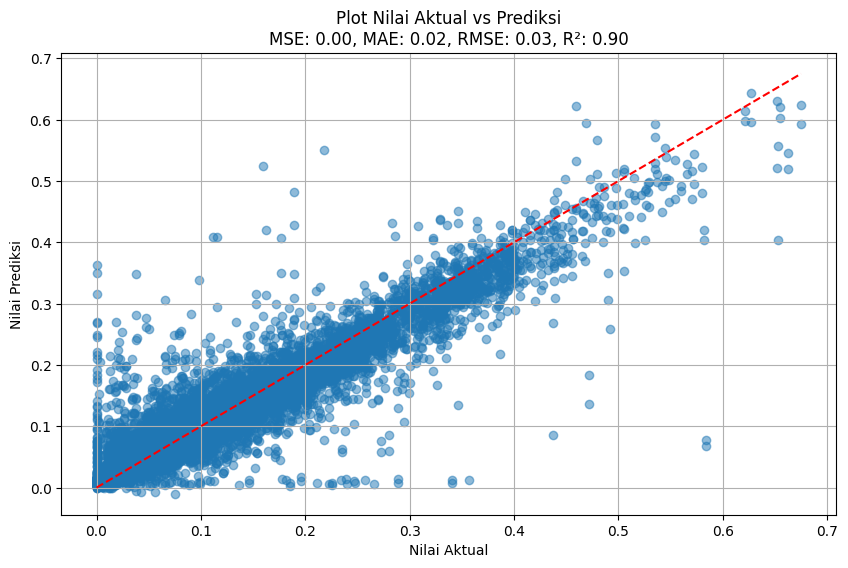

```python
from sklearn.metrics import mean_absolute_error, r2_score
    import numpy as np
    import matplotlib.pyplot as plt

    # Membuat model regresi linier
    model = LinearRegression()
    model.fit(X_train, y_train)

    # Memprediksi harga menggunakan model
    y_pred = model.predict(X_test)

    # Menghitung evaluasi metrik
    mse = mean_squared_error(y_test, y_pred)
    mae = mean_absolute_error(y_test, y_pred)
    rmse = np.sqrt(mse)
    r2 = r2_score(y_test, y_pred)

    # Menampilkan evaluasi metrik
    print(f'Mean Squared Error (MSE): {mse:.2f}')
    print(f'Mean Absolute Error (MAE): {mae:.2f}')
    print(f'Root Mean Squared Error (RMSE): {rmse:.2f}')
    print(f'R-squared (R²): {r2:.2f}')

    # Membuat plot
    plt.figure(figsize=(10, 6))
    plt.scatter(y_test, y_pred, alpha=0.5)
    plt.plot([y_test.min(), y_test.max()], [y_test.min(), y_test.max()], 'r--')  # Garis identitas
    plt.xlabel('Nilai Aktual')
    plt.ylabel('Nilai Prediksi')
    plt.title(f'Plot Nilai Aktual vs Prediksi\nMSE: {mse:.2f}, MAE: {mae:.2f}, RMSE: {rmse:.2f}, R²: {r2:.2f}')
    plt.grid()
    plt.show()
```

## Random Forest

```
Mean Squared Error (MSE): 0.00
    Mean Absolute Error (MAE): 0.02
    Root Mean Squared Error (RMSE): 0.03
    R-squared (R²): 0.88
```

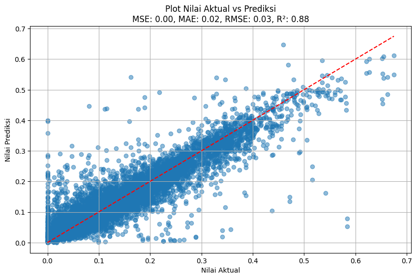

```python
from sklearn.ensemble import RandomForestRegressor
    from sklearn.metrics import mean_absolute_error, mean_squared_error, r2_score
    import numpy as np
    import matplotlib.pyplot as plt

    # Membuat model Random Forest
    model_rf = RandomForestRegressor(n_estimators=100, random_state=42)
    model_rf.fit(X_train, y_train)

    # Memprediksi harga menggunakan model Random Forest
    y_pred_rf = model_rf.predict(X_test)

    # Menghitung evaluasi metrik
    mse_rf = mean_squared_error(y_test, y_pred_rf)
    mae_rf = mean_absolute_error(y_test, y_pred_rf)
    rmse_rf = np.sqrt(mse_rf)
    r2_rf = r2_score(y_test, y_pred_rf)

    # Menampilkan evaluasi metrik
    print(f'Mean Squared Error (MSE): {mse_rf:.2f}')
    print(f'Mean Absolute Error (MAE): {mae_rf:.2f}')
    print(f'Root Mean Squared Error (RMSE): {rmse_rf:.2f}')
    print(f'R-squared (R²): {r2_rf:.2f}')

    # Membuat plot
    plt.figure(figsize=(10, 6))
    plt.scatter(y_test, y_pred_rf, alpha=0.5)
    plt.plot([y_test.min(), y_test.max()], [y_test.min(), y_test.max()], 'r--')  # Garis identitas
    plt.xlabel('Nilai Aktual')
    plt.ylabel('Nilai Prediksi')
    plt.title(f'Plot Nilai Aktual vs Prediksi\nMSE: {mse_rf:.2f}, MAE: {mae_rf:.2f}, RMSE: {rmse_rf:.2f}, R²: {r2_rf:.2f}')
    plt.grid()
    plt.show()
```